# 2_lineplots_boxplots_heatmaps

Author

Juan Garbayo - Data Insights and Visualization - IE University

# Libraries

For this notebook we are going to require to load the library `fpp3` and the package `reshape2`, since it contains some interesting sample datasets on time series. Run the code below to install `fpp3` and `reshape2`.

```r
install.packages("fpp3", dependencies = TRUE)
install.packages("reshape2", dependencies = TRUE)
```

```r
library(fpp3)
library(tidyverse)
library(reshape2)
```

# Line plots - `geom_line()`

The typical use for `geom_line()` is time series data, where we have records of a given observational unit over time. For example, the dataset `aus_arrivals`, loaded along `fpp3`, contains records of the number of arrivals to Australia from different countries of origin: `Japan`, `NZ`, `UK` and `US`.

In these case we have four observational units that we measure over time:

1. Arrivals from Japan to Australia
2. Arrivals from New Zealand to Australia
3. Arrivals from UK to Australia
4. Arrivals from US to Australia

Lets confirm the unique values of the variable `Origin`

```r
aus_arrivals
```

```
# A tsibble: 508 x 3 [1Q]
# Key:       Origin [4]
   Quarter Origin Arrivals
     <qtr> <chr>     <int>
 1 1981 Q1 Japan     14763
 2 1981 Q2 Japan      9321
 3 1981 Q3 Japan     10166
 4 1981 Q4 Japan     19509
 5 1982 Q1 Japan     17117
 6 1982 Q2 Japan     10617
 7 1982 Q3 Japan     11737
 8 1982 Q4 Japan     20961
 9 1983 Q1 Japan     20671
10 1983 Q2 Japan     12235
# … with 498 more rows
```

```r
# Unique values of variable Origin (country of origin)
aus_arrivals %>% pull(Origin) %>% unique()
```

```
[1] "Japan" "NZ"    "UK"    "US"
```

First let us use `geom_line()` to create a plot of the arrivals to australia from Japan. For convenience, we are going to store the resulting ggplot graph in a new object called `p1` (plot 1)

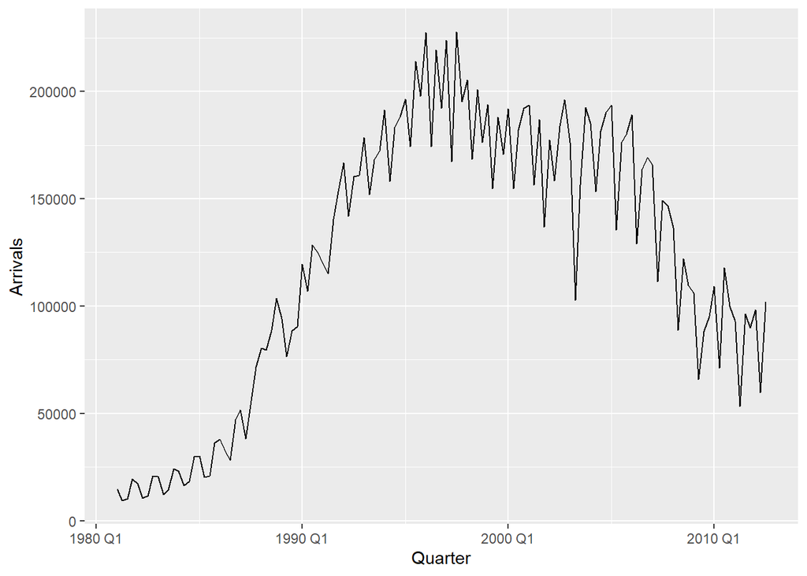

```r
p1 <-
  aus_arrivals %>%
    filter(Origin == "Japan") %>% # Limit observations to those from Japan
    ggplot(aes(x = Quarter, y = Arrivals)) +
    geom_line()

# Show p1
p1
```

## geom_line() + geom_point()

Importantly, note that the lines are joining together discrete observations! That is, we do not have a continuous measure of the arrivals from Japan to Australia, but rather only observations every quarter. This is most clear when we super-impose the specific observations with `geom_point()`. Starting from the previous ggpplot object `p1`, we may add a geom_point() layer to it:

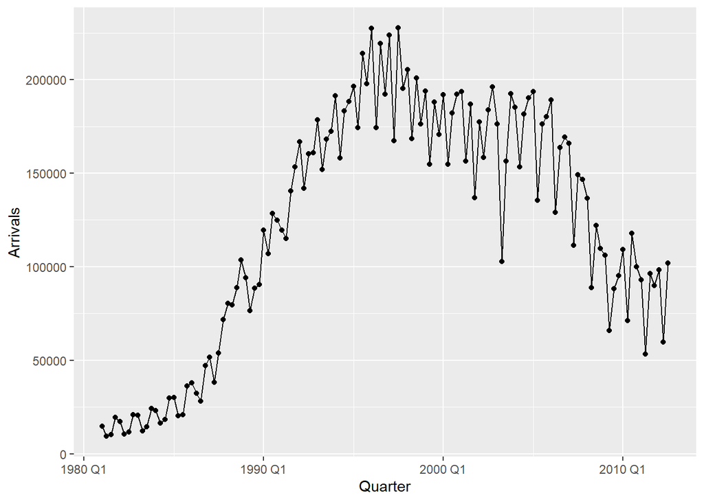

```r
p1 + geom_point()
```

Most of the time the points depicting the exact observations are committed from a line plot, but other times they may be included, depending on how explicit you want/need to be about them.

## `groups` and `color`

The `groups` argument can be used to create a different line for each group. This may be necessary in cases where we have a time series for different observational units in our dataset. For example, in the datset `aus_arrivals` we have time series for the arrivals to Australia from different countries of origin. In this case *each country of origin is a different observational unit*.

If we want to depict a different line plot for every observational unit (in this case country of origin), we need to specify these observational units as the `groups` argument within `aes`.

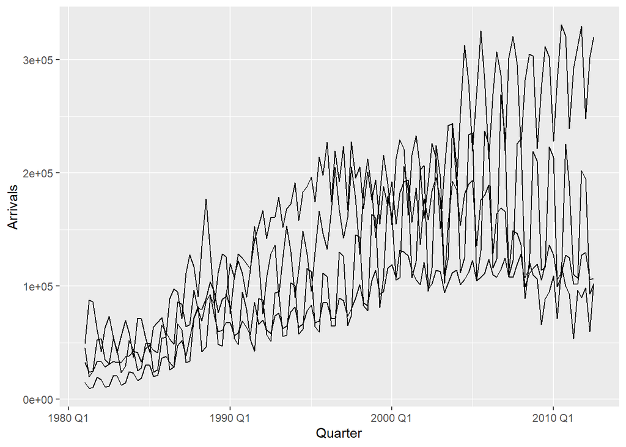

```r
aus_arrivals %>%
  ggplot(aes(x = Quarter, y = Arrivals,
             group = Origin)) +
  geom_line()
```

However, that graph is not very clear, because every line is black. To solve this issue, we may directly specify the groups using the argument `color` (**`groups` is now no longer necessary, it becomes redundant with colors**):

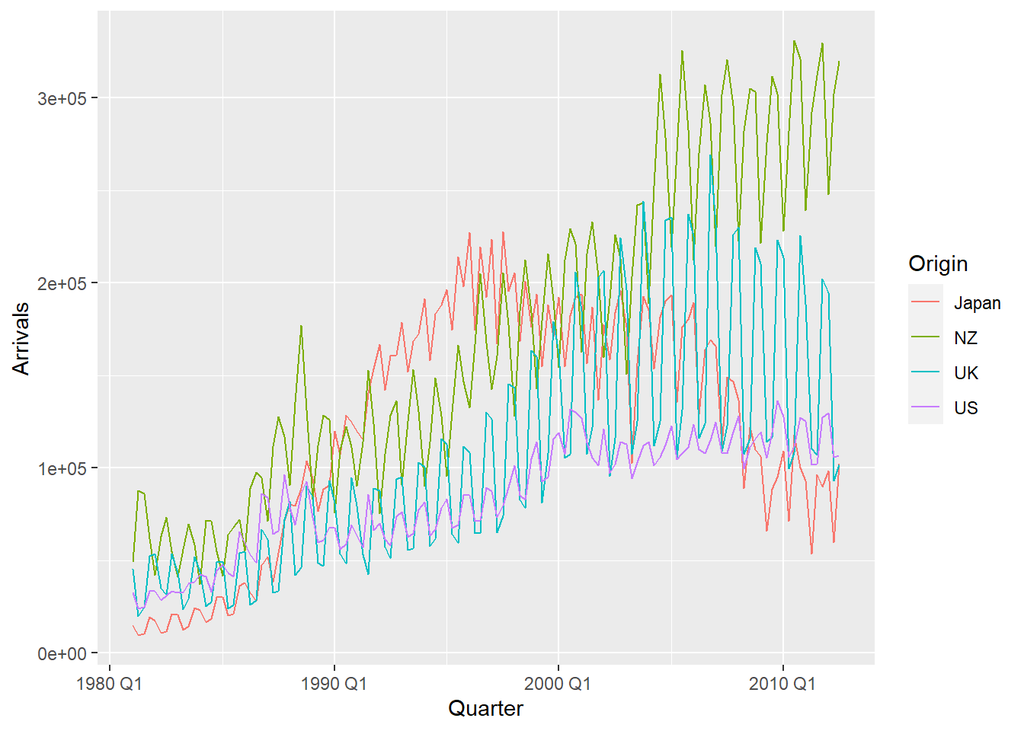

```r
aus_arrivals %>%
  ggplot(aes(x = Quarter, y = Arrivals,
             color = Origin)) +
  geom_line()
```

What happens if we do not use the variable `Origin` to segregate `groups` or by `color`?? Then *for every quarter (for every point in the x-axis) we would have four observations*. `geom_line()` would join these with a vertical line and then continue to the next quarter (next x-axis point). This graph would not make any sense at all. This is easiest to see if we overlay the observations using `geom_point()` to understand what is going on. **The graph below is wrong but we plot it to illustrate the previous points**:

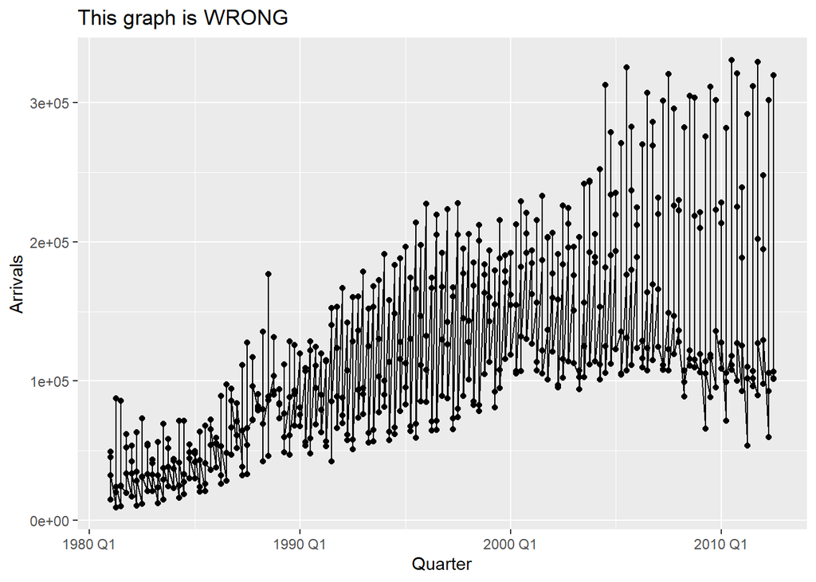

```r
# This graph is WRONG
aus_arrivals %>%
  ggplot(aes(x = Quarter, y = Arrivals)) +
  geom_line() +
  geom_point() +
  ggtitle("This graph is WRONG")
```

## `geom_line()` + facetting

Of course, facetting is also applicable. In fact, an alternative to using `groups` to depict the four countries of origin within the same graph would be to use `facet_wrap()`:

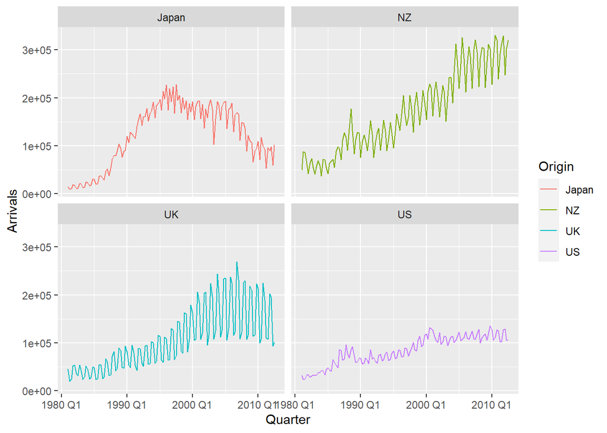

```r
aus_arrivals %>%
  ggplot(aes(x = Quarter, y = Arrivals,
             color = Origin)) +
  geom_line() +
  facet_wrap("Origin")
```

We could also have used `facet_grid()`. In this particular case we only want to facet following a single variable (`Origin`), so we need to use `.` to indicate this. Remember the syntax:

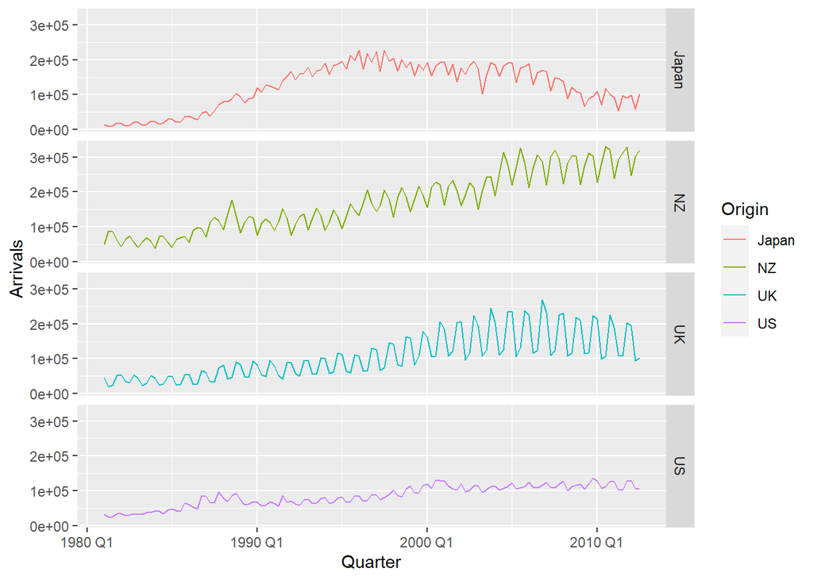

```r
aus_arrivals %>%
  ggplot(aes(x = Quarter, y = Arrivals,
             color = Origin)) +
  geom_line() +
  facet_grid(Origin ~ .) # facet the variable Origin row-wise
```

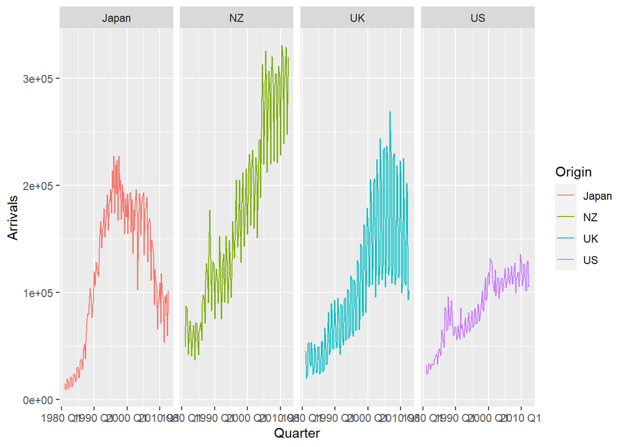

```r
aus_arrivals %>%
  ggplot(aes(x = Quarter, y = Arrivals,
             color = Origin)) +
  geom_line() +
  facet_grid(. ~ Origin) # facet the variable Origin column-wise
```

## `geom_line()` + `geom_smooth()`

You may add a smoothing line to `geom_line()` to **identify the evolution of the trend regardless of the short-term fluctuations**. Use a non-linear method such as `"gam"` (or `loess` if you have less than 1000 points) and specify `se = FALSE` to remove the confidence intervals (`se` stands for *standard error*):

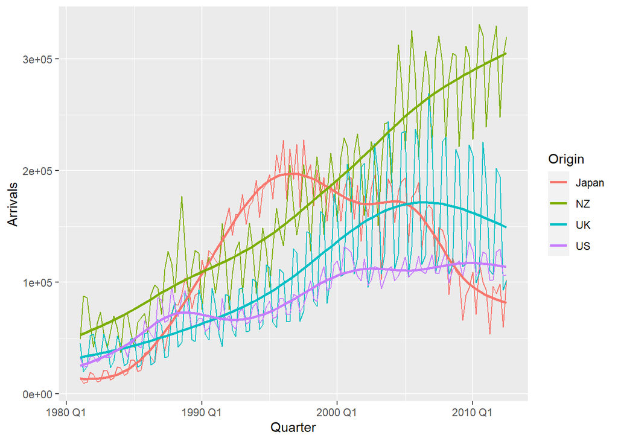

```r
  aus_arrivals %>%
    ggplot(aes(x = Quarter, y = Arrivals,
               color = Origin)) +
    geom_line() +
    geom_smooth(method = "gam", se = FALSE)
```

Note that, because we specified the argument `color` within the highest level `aes()` (the one within the function `ggplot()`), the colouring also applies to `geom_smooth()`.

For noisy data, smoothing is sensible as well. For example, the dataset `vic_elec` contains half-hourly electricity consumption (average value) for the region of Victoria in Australia. Because of the high number of measurements, and the fluctuations in energy consumption within the day, weeks and months (different time periods), the data is very noisy. We may extract a trend using `geom_smooth()`

```r
vic_elec
```

```
# A tsibble: 52,608 x 5 [30m] <Australia/Melbourne>
   Time                Demand Temperature Date       Holiday
   <dttm>               <dbl>       <dbl> <date>     <lgl>
 1 2012-01-01 00:00:00  4383.        21.4 2012-01-01 TRUE
 2 2012-01-01 00:30:00  4263.        21.0 2012-01-01 TRUE
 3 2012-01-01 01:00:00  4049.        20.7 2012-01-01 TRUE
 4 2012-01-01 01:30:00  3878.        20.6 2012-01-01 TRUE
 5 2012-01-01 02:00:00  4036.        20.4 2012-01-01 TRUE
 6 2012-01-01 02:30:00  3866.        20.2 2012-01-01 TRUE
 7 2012-01-01 03:00:00  3694.        20.1 2012-01-01 TRUE
 8 2012-01-01 03:30:00  3562.        19.6 2012-01-01 TRUE
 9 2012-01-01 04:00:00  3433.        19.1 2012-01-01 TRUE
10 2012-01-01 04:30:00  3359.        19.0 2012-01-01 TRUE
# … with 52,598 more rows
```

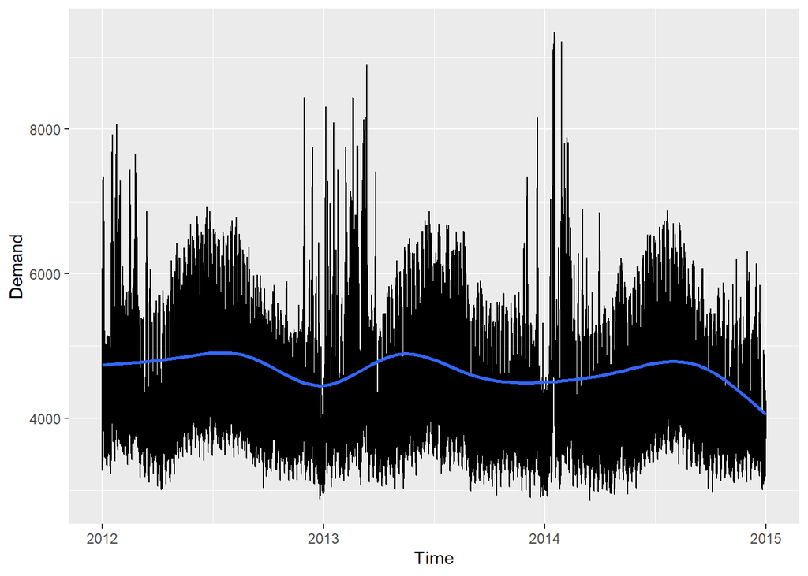

```r
vic_elec %>%
  ggplot(aes(x=Time, y=Demand)) +
  geom_line() +
  geom_smooth(method = "gam", se = FALSE)
```

## Exercise LP. 1

The dataset `global_economy`, loaded along with the library `fpp3` contains multiple time series of different economic measures for a number of countries. Let us first filter the data corresponding to Spain’s imports and exports

```r
sp_exports_imports <-
  global_economy %>%
  filter(Country == "Spain") %>%
  select(Year, Imports, Exports)

sp_exports_imports
```

```
# A tsibble: 58 x 3 [1Y]
    Year Imports Exports
   <dbl>   <dbl>   <dbl>
 1  1960    6.90    8.37
 2  1961    8.60    7.97
 3  1962   10.1     8.30
 4  1963   10.8     7.71
 5  1964   11.4     8.81
 6  1965   13.1     8.19
 7  1966   13.6     8.89
 8  1967   11.9     8.55
 9  1968   12.6    10.6
10  1969   13.1    11.3
# … with 48 more rows
```

Currently the dataset is such that it has:

1. One row per year
2. Imports registered in one column and Exports registered in another column

To be able to handle this data more easily in `ggplot2`, it is sensible to reformat it. Specifically we want to:

1. Create a new categorical variable called `measure` that will take the values either `Imports` or `Exports`
2. Expand the number of rows of the dataset to have two rows per year. One row will correspond to `Imports` and one row to `Exports`
3. A third column called `values` will hold the corresponding value of `Imports` and `Exports` within each year.

That is, we want our dataset to look as follows:

```
# A tsibble: 116 x 3 [1Y]
# Key:       measure [2]
    Year measure value
   <dbl> <chr>   <dbl>
 1  1960 Imports  6.90
 2  1960 Exports  8.37
 3  1961 Imports  8.60
 4  1961 Exports  7.97
 5  1962 Imports 10.1
 6  1962 Exports  8.30
 7  1963 Imports 10.8
 8  1963 Exports  7.71
 9  1964 Imports 11.4
10  1964 Exports  8.81
# … with 106 more rows
```

We can achieve this using `pivot_longer()` from the library `dplyr` as follows:

```r
sp_exports_imports <-
  sp_exports_imports %>%
  pivot_longer(cols = Imports:Exports, # Columns we want to re-shape (cols from Imports to Exports)
               names_to = "measure", # Name of the new categorical variable
               values_to = "value")

sp_exports_imports
```

```
# A tsibble: 116 x 3 [1Y]
# Key:       measure [2]
    Year measure value
   <dbl> <chr>   <dbl>
 1  1960 Imports  6.90
 2  1960 Exports  8.37
 3  1961 Imports  8.60
 4  1961 Exports  7.97
 5  1962 Imports 10.1
 6  1962 Exports  8.30
 7  1963 Imports 10.8
 8  1963 Exports  7.71
 9  1964 Imports 11.4
10  1964 Exports  8.81
# … with 106 more rows
```

This format may indeed be less clear for a human reader, but from `ggplot`’s perspective it is better, because it allows us to specify the values `Imports` and `Exports` within the `aes()` function as the values of a single categorical variable called `measure`.

**NOTE: `pivot_longer()` and `pivot_wider()`** are **important dataframe operations when working with ggplot2** and you should become familiar with them. A short notebook dedicated to explaining these operations will be released.

Now that you have the data in an appropriate format for ggplot() to work with it, create the following graphs:

- **HINT** use `+ ylab("% of GDP")` to label the y-axis and `+ ggtitle("Spain's Exports and Imports")` to print the title.

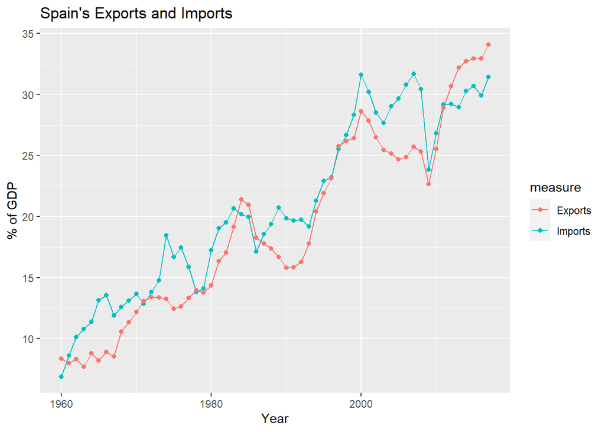

```r
sp_exports_imports %>%
  ggplot(aes(x = Year, y = value, color = measure)) +
  geom_line() +
  geom_point() +
  ylab("% of GDP") +
  ggtitle("Spain's Exports and Imports")
```

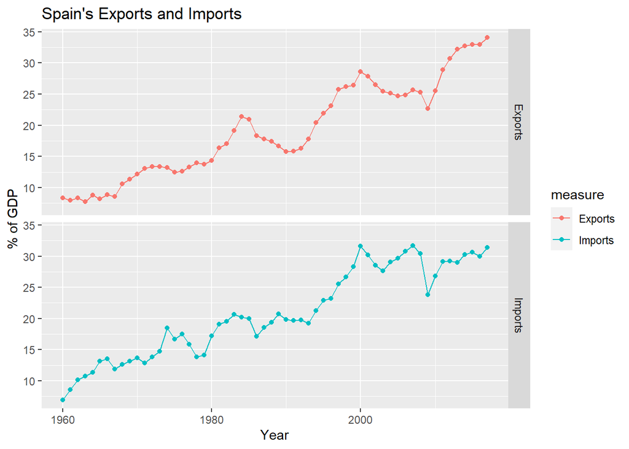

```r
sp_exports_imports %>%
  ggplot(aes(x = Year, y = value, color = measure)) +
  geom_line() +
  geom_point() +
  facet_grid(measure ~ .) +
  ylab("% of GDP") +
  ggtitle("Spain's Exports and Imports")
```

## Exercise LP. 2

We are going to use the library `nycflights13`, which loads the dataset detailing all the flights departing from the three New York City airports in 2013. Remember you need to install this package and then load it

```r
# Run this if you do not have installed the package yet
install.packages("nycflights13", dependencies = TRUE)
```

```r
# Run this to load the library
library(nycflights13)
# Run this to show the dataset
flights
```

```
# A tibble: 336,776 × 19
    year month   day dep_time sched_de…¹ dep_d…² arr_t…³ sched…⁴ arr_d…⁵ carrier
   <int> <int> <int>    <int>      <int>   <dbl>   <int>   <int>   <dbl> <chr>
 1  2013     1     1      517        515       2     830     819      11 UA
 2  2013     1     1      533        529       4     850     830      20 UA
 3  2013     1     1      542        540       2     923     850      33 AA
 4  2013     1     1      544        545      -1    1004    1022     -18 B6
 5  2013     1     1      554        600      -6     812     837     -25 DL
 6  2013     1     1      554        558      -4     740     728      12 UA
 7  2013     1     1      555        600      -5     913     854      19 B6
 8  2013     1     1      557        600      -3     709     723     -14 EV
 9  2013     1     1      557        600      -3     838     846      -8 B6
10  2013     1     1      558        600      -2     753     745       8 AA
# … with 336,766 more rows, 9 more variables: flight <int>, tailnum <chr>,
#   origin <chr>, dest <chr>, air_time <dbl>, distance <dbl>, hour <dbl>,
#   minute <dbl>, time_hour <dttm>, and abbreviated variable names
#   ¹sched_dep_time, ²dep_delay, ³arr_time, ⁴sched_arr_time, ⁵arr_delay
```

The code below:

1. Creates a column `date` indicating the date of each flight using `make_date()` from the library `lubridate`.
2. Computes the `av_delay`, `max_delay` and `min_delay` of the flights upon arrival to their destination for each of the three airports of origin in NY (variable `origin`) for a given `date`.
3. Re-orders the columns, placing `date`, `wday` and `month` at the front and then every other column present

```r
# Load lubridate if it is not loaded
# Load nycflights if it is not loaded
library(nycflights13)
library(lubridate) # In case it is not loaded.
                   # This should not be placed here, but I put it to prevent
                   # errors in your code. PLace it at the beginning of the document
library(tidyverse) # In case it is not loaded.
                   # This should not be placed here, but I put it to prevent
                   # errors in your code. PLace it at the beginning of the document

delays <-

  flights %>%

    # 1. Create a new date column
    mutate(
      date = make_date(year, month, day)
    ) %>%

    # 2. group_by and summarise
    #    the variables month and day are included so that
    #    they are present in the summary dataframe, but they do not affect
    #    the computation.
    group_by(month, day, origin, date) %>%
    summarise(
      av_delay = mean(arr_delay, na.rm = TRUE),
      max_delay = max(arr_delay, na.rm = TRUE),
      min_delay = min(arr_delay, na.rm = TRUE)
    ) %>%

    # So that subsequent operations are not performed group-wise
    ungroup() %>%

    # 3. Reorder columns
    select(date, month, everything())
delays
```

```
# A tibble: 1,095 × 7
   date       month   day origin av_delay max_delay min_delay
   <date>     <int> <int> <chr>     <dbl>     <dbl>     <dbl>
 1 2013-01-01     1     1 EWR       20.9        456       -31
 2 2013-01-01     1     1 JFK        8.09       851       -48
 3 2013-01-01     1     1 LGA        7.89       145       -35
 4 2013-01-02     1     2 EWR       25.4        323       -52
 5 2013-01-02     1     2 JFK        3.27       368       -59
 6 2013-01-02     1     2 LGA        7.66       359       -29
 7 2013-01-03     1     3 EWR        6.10       176       -53
 8 2013-01-03     1     3 JFK        1.77       285       -65
 9 2013-01-03     1     3 LGA       10.2        257       -37
10 2013-01-04     1     4 EWR        1.77       276       -61
# … with 1,085 more rows
```

With the above dataset, generate the following plot:

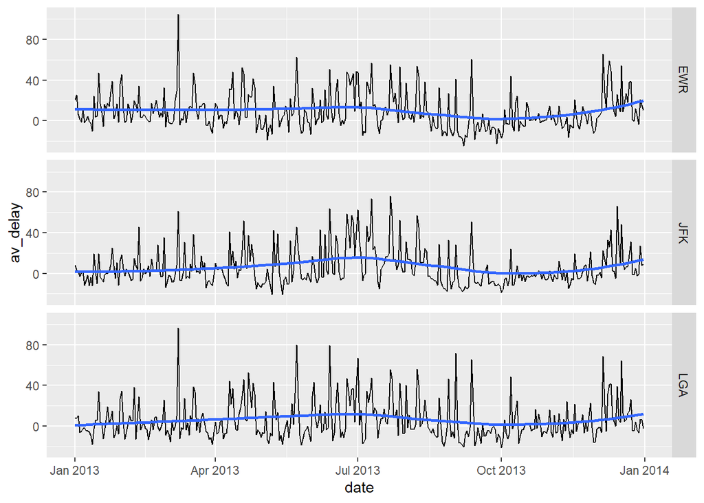

```r
ggplot(delays, aes(x = date, y = av_delay)) +
  geom_line() +
  geom_smooth(se = FALSE) +
  facet_grid(origin ~ .)
```

# Boxplots - `geom_boxplot()`

A box-plot is a plot summarizing a distribution. It represents in a succint manner the following magnitudes of a given distribution/sample (the figure below follows Tukey’s classic definition, the defauly in `ggplot`):

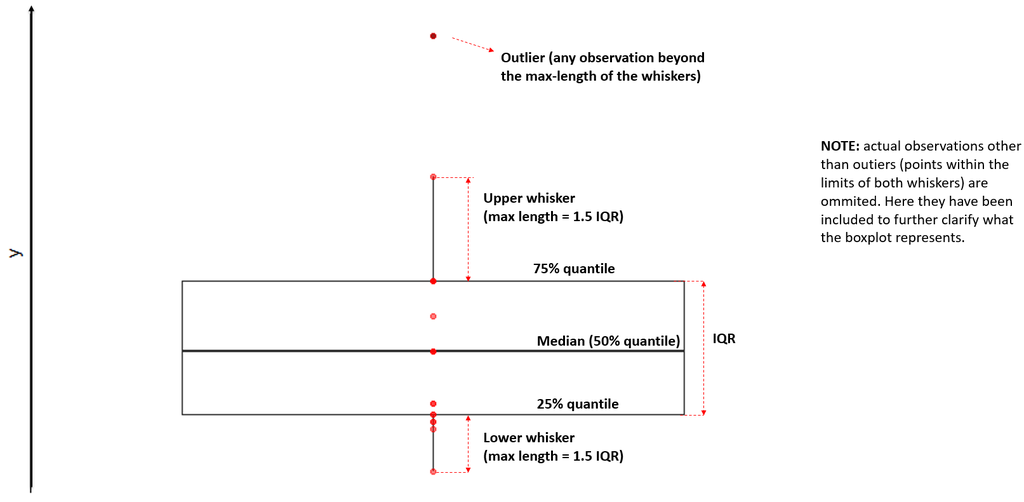

Box-plot - standard Tukey’s definition

The figure above includes the actual observations summarized by the box-plot (red points). These are normally ommited, since the box-plot is a summary. The final aspect would therefore be:

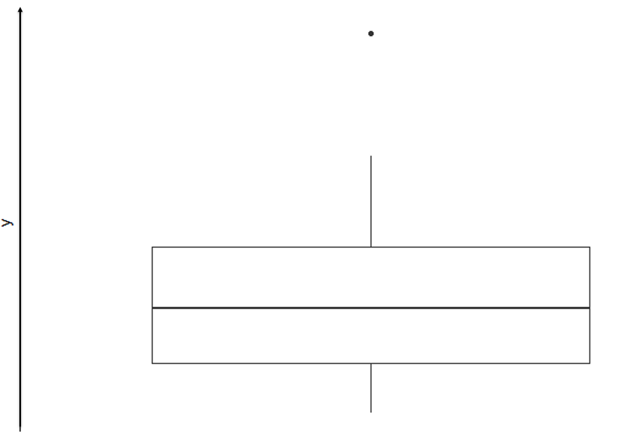

## Boxplots in ggplot2

We can use `geom_boxplot()` to produce boxplots in `ggplot2`. For example, we might produce box-plots to summarize the distributions of the depth of diamonds for the different cuts:

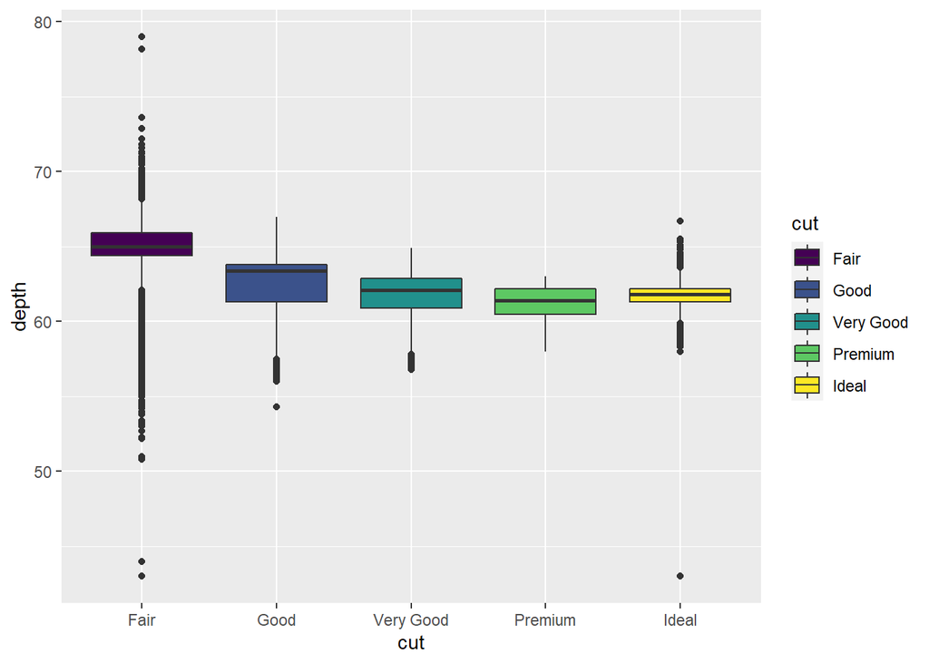

```r
ggplot(diamonds, aes(y=depth, x=cut, fill= cut)) +
  geom_boxplot()
```

These boxplots tell us that the diamonds of cut `Fair` have many more outliers in terms of depth than the rest of the categories. They also have a noticeable greater median depth. Diamonds with cut `ideal` also have a substantial ammount of points that could be considered outliers or extremes of its distribution. Diamonds with cuts `Good`, `Very good`, `Premium` and `Ideal` have a fairly similar median depth.

We may even further split the study using the clarity within each color by specifying a `fill` following yet another categorical variable (in this case, `clarity`)

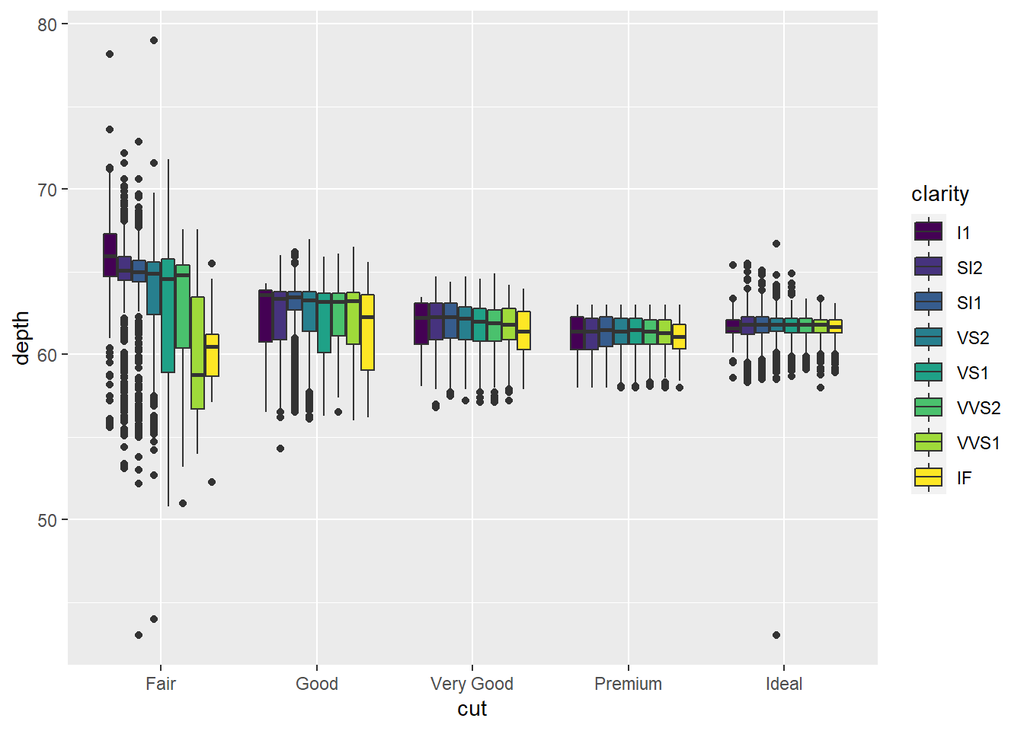

```r
ggplot(diamonds, aes(y=depth, x=cut, fill=clarity)) +
  geom_boxplot()
```

## Exercise BP. 1

Create the following graph:

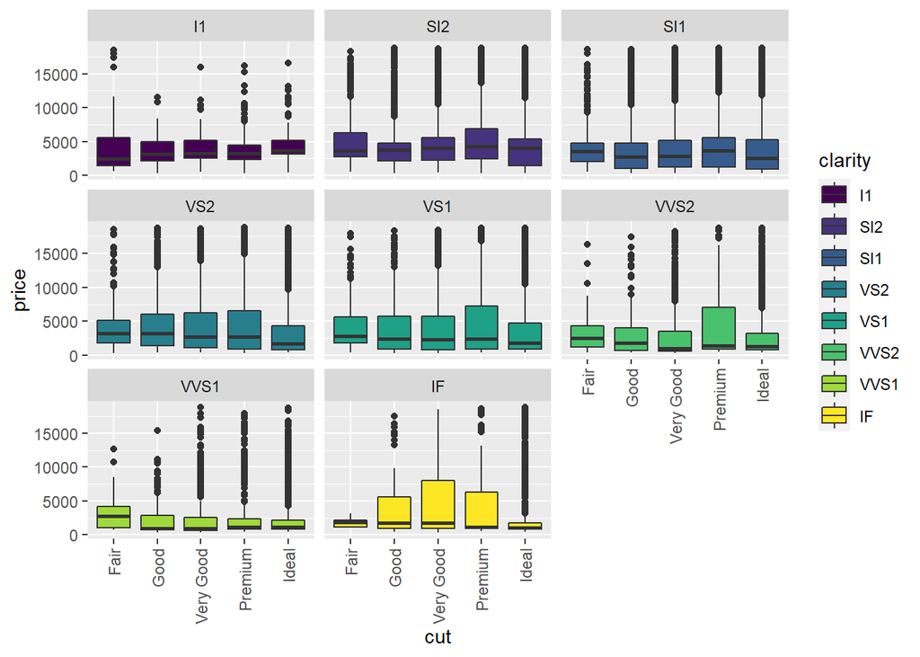

```r
ggplot(diamonds, aes(x = cut, y = price, fill = clarity)) +

  geom_boxplot() +

  facet_wrap("clarity") +

  theme(axis.text.x = element_text(angle = 90, vjust = 0.5, hjust=1))
```

## Time-series of box-plots

Box-plots can come in handy for the analysis of time-series data.

For example, the PBS dataset contained in the `fpp3` package details the costs of Medicare prescriptions Australia. Let us first filter for a specific kind of drugs (antidiabetic drugs, corresponding to `ATC2 == "A10"`) and then add all the costs per month (using group_by).

```r
a10 <-

PBS %>% as_tibble() %>%

  filter(ATC2 == "A10") %>%

  group_by(Month) %>%

  summarise(TotalC = sum(Cost) / 1e6)

a10
```

```
# A tibble: 204 × 2
      Month TotalC
      <mth>  <dbl>
 1 1991 Jul   3.53
 2 1991 Aug   3.18
 3 1991 Sep   3.25
 4 1991 Oct   3.61
 5 1991 Nov   3.57
 6 1991 Dec   4.31
 7 1992 Jan   5.09
 8 1992 Feb   2.81
 9 1992 Mar   2.99
10 1992 Apr   3.20
# … with 194 more rows
```

## Exercise LP. 3 - generate the graph below starting from the a10 dataframe

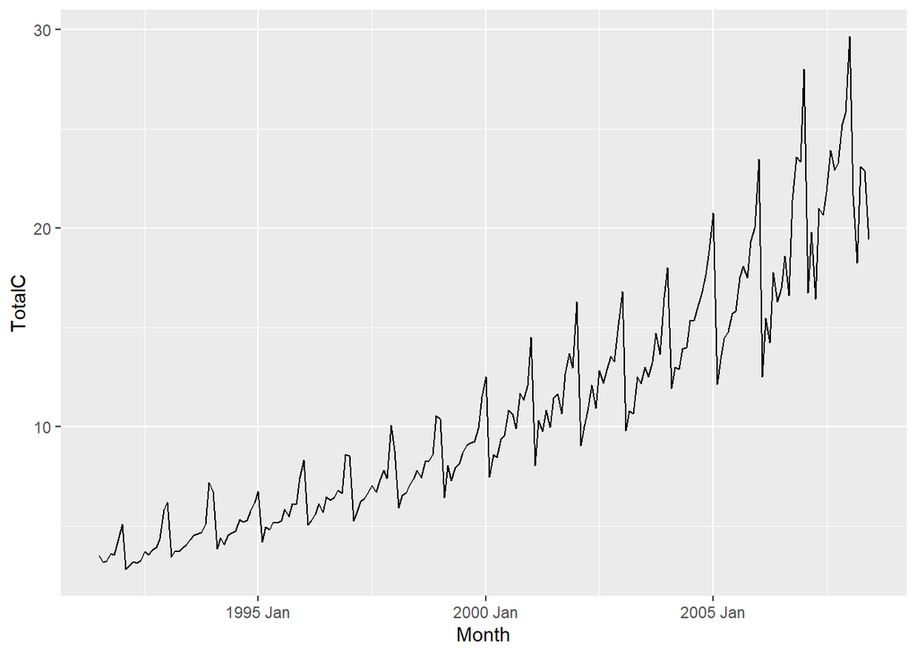

```r
a10 %>%
  ggplot(aes(x = Month, y = TotalC)) +
  geom_line()
```

## Exercise BP. 2 - `factor()`

Now using the function `year()` on the column `Month` of the `a10` dataframe, create a new variable (column) signalling the year for each observation and call it `year`. Then produce the graph below, which is a time series of box-plots summarising the distribution of observations within each year.

- **Hint:** you need to use `factor(year)` and not `year` as the x aesthetic for this to work. This signals to ggplot that it should treat the variable year as a categorical despite it being of type `double`.
- **NOTE:** the function `year()` is part of the `lubridate` package, which was loaded along with `fpp3`.

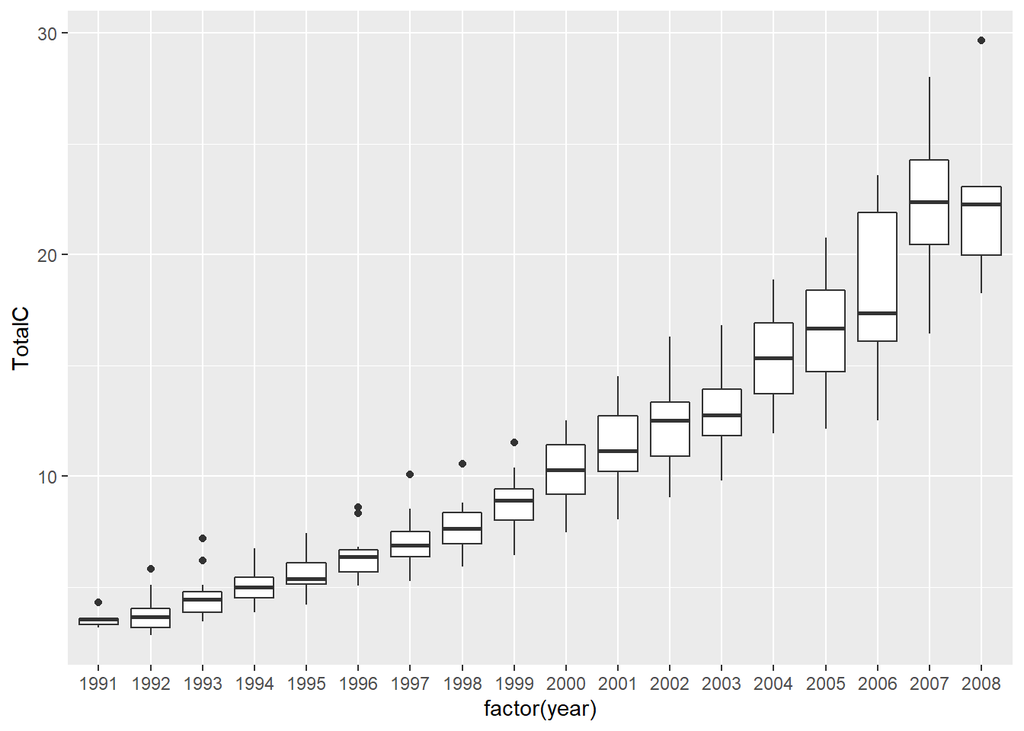

```r
a10 <-
  a10 %>%
  mutate(year = year(Month))

a10 %>%
  ggplot(aes(x = factor(year), y = TotalC)) +
  geom_boxplot()
```

## Exercise BP. 3 - New York City Flights

In exercise LP. 2 we generated the dataset `delays` from the `flights` dataset of the library `nycflights13`. Refer to that exercise for the dtails.

Using `delays` produce the graph below:

HINTs:

- use `xlab("month")`
- use `ylab("max delay on arrival (minutes)")`
- use `ggtitle("Variability of max delays")`

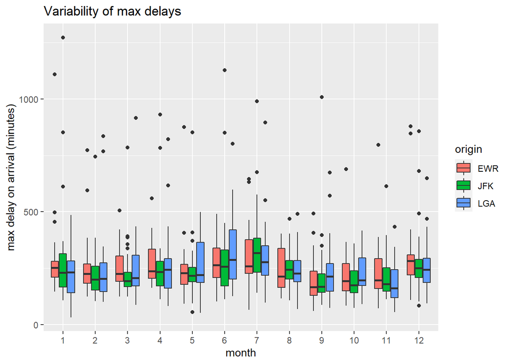

```r
ggplot(delays, aes(x = factor(month), y = max_delay, fill = origin)) +

  geom_boxplot() +

  xlab("month") +
  ylab("max delay on arrival (minutes)") +

  ggtitle("Variability of max delays")
```

# Heatmaps - `geom_tile()`

To generate a heatmap you need:

- Two categorical variables one for the x-axis and one for the y-axis
- One continuous variable to be used as the `fill` argument of `aes`

## Heatmap example 1 - total value of diamonds in the dataset in each subgroup of color and cut

The first thing we need to do is to use `group_by()` to compute the sum of the prices of all the diamonds within each group defined by `cut` and `color`.

```r
diamonds_val <-
  diamonds %>%
    group_by(cut, color) %>%
    summarize(
      value = sum(price, na.rm=TRUE)
    ) %>%
    ungroup()
```

[output not shown]

```r
diamonds_val
```

```
# A tibble: 35 × 3
   cut   color   value
   <ord> <ord>   <int>
 1 Fair  D      699443
 2 Fair  E      824838
 3 Fair  F     1194025
 4 Fair  G     1331126
 5 Fair  H     1556112
 6 Fair  I      819953
 7 Fair  J      592103
 8 Good  D     2254363
 9 Good  E     3194260
10 Good  F     3177637
# … with 25 more rows
```

Once we have this, let us see how we could generate a heat map and examine its output:

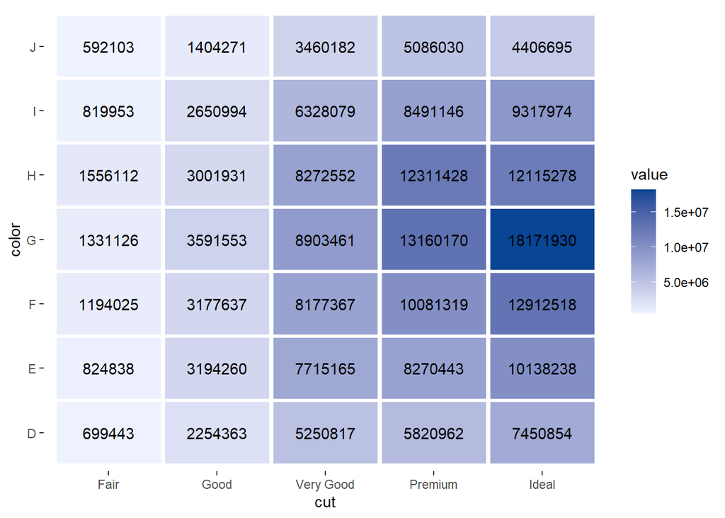

```r
ggplot(diamonds_val, aes(x=cut, y=color, fill=value)) +

  # Create tiles and adjust their areas to ensure adequate spacing between them
  geom_tile(aes(width=0.96, height = 0.95)) +

  # Print the values within each tile
  geom_text(aes(label=value)) +

  # Define a custom color scale.
  scale_fill_gradient(low="#eff3ff", high="#084594") +

  # Use white background to enhance spacing effect between tiles
  theme(panel.background=element_rect(fill='white'))
```

### Choosing grading colors

For the time being, suffice it to say that there are databases offering guidance,

[Colorbrewer](https://colorbrewer2.org/#type=sequential&scheme=BuGn&n=3)

We will delve further into color scales in the session devoted to graphs customization.

## Heatmap example 2 - correlation matrix - diamonds dataset

A correlation matrix can be made very clear using a heatmap visualization.

First, we select all the numerical variables (the ones for which it makes sense to compute the correlation coefficient). We do this by using `where(is.numeric)` in combination with select. Let us understand how this works:

- `is.numeric` returns `TRUE` if a given variable or vector is of type numeric. For example, the code below evaluates to `TRUE` because the variable `carat` is of type numeric:

```r
diamonds %>% pull(carat) %>% is.numeric()
```

```
[1] TRUE
```

- `where()` is a function that can be used to select variables of a dataframe for which a function returns TRUE. For example, the code below selects all the numerical variables (columns for which `is.numeric()` evaluates to true):

```r
# Select variables for which the function
diamonds %>% select(where(is.numeric))
```

```
# A tibble: 53,940 × 7
   carat depth table price     x     y     z
   <dbl> <dbl> <dbl> <int> <dbl> <dbl> <dbl>
 1  0.23  61.5    55   326  3.95  3.98  2.43
 2  0.21  59.8    61   326  3.89  3.84  2.31
 3  0.23  56.9    65   327  4.05  4.07  2.31
 4  0.29  62.4    58   334  4.2   4.23  2.63
 5  0.31  63.3    58   335  4.34  4.35  2.75
 6  0.24  62.8    57   336  3.94  3.96  2.48
 7  0.24  62.3    57   336  3.95  3.98  2.47
 8  0.26  61.9    55   337  4.07  4.11  2.53
 9  0.22  65.1    61   337  3.87  3.78  2.49
10  0.23  59.4    61   338  4     4.05  2.39
# … with 53,930 more rows
```

We make use of this to **select only the numeric variables prior to computing the correlation matrix**:

```r
corr_matrix <-

  diamonds %>%

    # Selects only variables of type "numeric" for which pearsons corr. coeff makes sense
    select(where(is.numeric)) %>%

    # Computes correlation matrix between the numerical variables
    cor()

corr_matrix
```

```
           carat       depth      table      price           x           y
carat 1.00000000  0.02822431  0.1816175  0.9215913  0.97509423  0.95172220
depth 0.02822431  1.00000000 -0.2957785 -0.0106474 -0.02528925 -0.02934067
table 0.18161755 -0.29577852  1.0000000  0.1271339  0.19534428  0.18376015
price 0.92159130 -0.01064740  0.1271339  1.0000000  0.88443516  0.86542090
x     0.97509423 -0.02528925  0.1953443  0.8844352  1.00000000  0.97470148
y     0.95172220 -0.02934067  0.1837601  0.8654209  0.97470148  1.00000000
z     0.95338738  0.09492388  0.1509287  0.8612494  0.97077180  0.95200572
               z
carat 0.95338738
depth 0.09492388
table 0.15092869
price 0.86124944
x     0.97077180
y     0.95200572
z     1.00000000
```

The result is an R matrix. We have not seen this data structure, but you may think of it as a two-dimensional vector. In any case, we are going to turn it into a dataframe using:

1. The function `reshape2::melt()` (function `melt()` from the `reshape2` package). Turns the wide-format `corr_matrix` to long format. This will leave the data in a format much more adequate for ggplot2.
2. Then we will round the correlation coefficients to 2 decimals to be able to include them in our graph

Let us proceed with `reshape2::melt`

```r
aux_corr <-

  corr_matrix %>%

  reshape2::melt()

aux_corr
```

```
    Var1  Var2       value
1  carat carat  1.00000000
2  depth carat  0.02822431
3  table carat  0.18161755
4  price carat  0.92159130
5      x carat  0.97509423
6      y carat  0.95172220
7      z carat  0.95338738
8  carat depth  0.02822431
9  depth depth  1.00000000
10 table depth -0.29577852
11 price depth -0.01064740
12     x depth -0.02528925
13     y depth -0.02934067
14     z depth  0.09492388
```

[output cut: 35 more lines]

The function `reshape2::melt()` is essentially equivalent to `pivot_longer()`, but applicable to an R matrix rather than a dataframe. Lets explain its output.

In the next step we round the column value to two decimals. This is necessary to print the actual value on the heatmap (you will understand this when you see the result):

```r
aux_corr <-
  aux_corr %>%
    mutate(
      value = round(value, 2)
    )

aux_corr
```

```
    Var1  Var2 value
1  carat carat  1.00
2  depth carat  0.03
3  table carat  0.18
4  price carat  0.92
5      x carat  0.98
6      y carat  0.95
7      z carat  0.95
8  carat depth  0.03
9  depth depth  1.00
10 table depth -0.30
11 price depth -0.01
12     x depth -0.03
13     y depth -0.03
14     z depth  0.09
```

[output cut: 35 more lines]

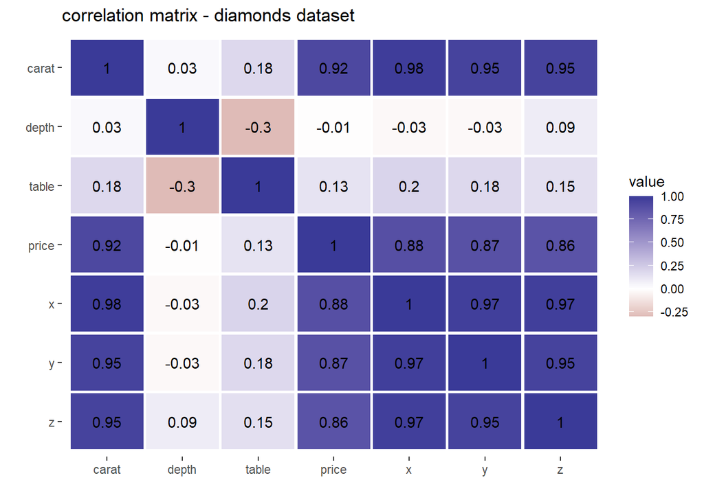

```r
aux_corr %>%

  ggplot(aes(x = Var1, y = Var2, fill = value)) + # Rev reverses the order of the
                                                   # categorical y axis

  # Create the tiles and adjust the area to ensure adequate spacing
  geom_tile(aes(width = 0.965, height = 0.95)) +

  # Reverse the y-axis so that the 1s of the matrix are on the main
  # diagonal of the matrix
  scale_y_discrete(limits=rev) +

  # Print the corr values within the tiles
  geom_text(aes(label=value)) +

  # Define a gradient color scale with two ends
  # Further on this command on  the notebook on graph customization
  scale_fill_gradient2() +

  # Use white background as spacing within the tiles
  theme(panel.background=element_rect(fill='white')) +

  ylab("") + xlab("") + # Remove the x-axis and y-axis labels

  ggtitle("correlation matrix - diamonds dataset") # print the title
```

Note that **we used `scale_fill_gradient2()` because the correlation coefficient has two relevant extreme values (-1 and 1), so our color scale requires two such extremes**. This **is explained in detail in the notebook on graphs customisation**, where we will repeat this example and learn how to further taylor the color scale.

## Heatmap example 3 - Calendar heatmap

The `vic_elec` dataset, from the `fpp3` package, contains half-hourly electricity consumption records for the region of Victoria in Australia.

The code below computes the average daily demand and then creates variables detailing the year, month and the day of the month corresponding to each date. Finally it filters observations corresponding to 2012 and stores the result in a variable called `aux` (*auxiliary*)

- **NOTE:** the functions `year()`, `month()` and `mday()` are part of the `lubridate` package, which was loaded along with `fpp3`.

```r
aux <-

vic_elec %>%

  as_tibble() %>% # Ensure the object is a tibble

  group_by(Date) %>% # GroupBy day

  # Compute average daily demand
  summarize(
    avg_demand_MWh = mean(Demand, na.rm=TRUE)
  ) %>%

  # Extract year, month and day of the month
  mutate(
    year = year(Date),
    month = month(Date, label = TRUE, abbr = FALSE),
    mday = mday(Date)
  ) %>%

  # Filter for observations in 2012
  filter(year == 2012)

aux
```

```
# A tibble: 366 × 5
   Date       avg_demand_MWh  year month    mday
   <date>              <dbl> <dbl> <ord>   <int>
 1 2012-01-01          4634.  2012 January     1
 2 2012-01-02          5374.  2012 January     2
 3 2012-01-03          5565.  2012 January     3
 4 2012-01-04          4640.  2012 January     4
 5 2012-01-05          4387.  2012 January     5
 6 2012-01-06          4380.  2012 January     6
 7 2012-01-07          4219.  2012 January     7
 8 2012-01-08          4029.  2012 January     8
 9 2012-01-09          4454.  2012 January     9
10 2012-01-10          4480.  2012 January    10
# … with 356 more rows
```

Finally the code below computes the calendar heatmap:

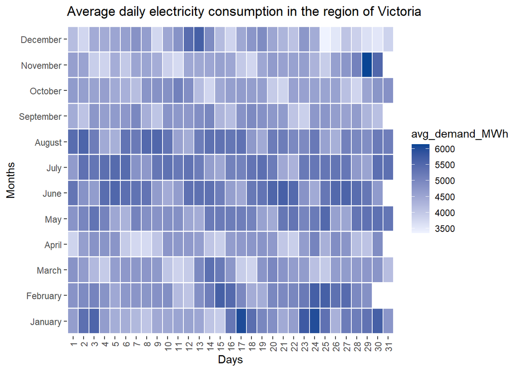

```r
aux %>%

  ggplot(aes(x = factor(mday), y = month, fill = avg_demand_MWh)) +

  # Create the tiles and adjust heir areas to ensure adequate spacing
  geom_tile(aes(width=.93, height=.955)) +

  theme(
        # Set background to white to show between tiles
        panel.background=element_rect(fill='white'),

        # Rotate the labels of the x-axis
        axis.text.x = element_text(angle = 90, vjust = 0.5, hjust=1)
        ) +

  # Define custom gradient scale
  scale_fill_gradient(low="#eff3ff", high="#084594") +

  # Set label for x-axis
  xlab("Days") +

  # Set label for y-axis
  ylab("Months") +

  # Set title
  ggtitle("Average daily electricity consumption in the region of Victoria")
```

## Exercise HM. 1 - Heatmap calendar of weekly data

The dataset `us_gasoline` contains the finished motor gasoline product supplied in the US in *million barrels per day*.

The code below computes variables corresponding to the year - month and week of each observation and finally filters for years between 2010 and 2016 (included)

- **NOTE:** the functions `year()`, `month()` and `epiweek()` are part of the `lubridate` package, which was loaded along with `fpp3`.

```r
aux_gasoline <-

  # Dataset loaded along the fpp3 library
  us_gasoline %>%

    # Ensure the data is a tibble and not a dataframe
    as_tibble() %>%

    # Create new variables for the year, month and week of the year
    mutate(
      year = year(Week),
      month = month(Week, label = TRUE, abbr = FALSE),
      week = epiweek(Week)
    ) %>%

  # Fitlter for years between 2010 and 2016 (included)
  filter(year >= 2010) %>%
  filter(year < 2017)

aux_gasoline
```

```
# A tibble: 365 × 5
       Week Barrels  year month     week
     <week>   <dbl> <dbl> <ord>    <dbl>
 1 2010 W01    8.74  2010 January      1
 2 2010 W02    8.60  2010 January      2
 3 2010 W03    8.62  2010 January      3
 4 2010 W04    8.61  2010 January      4
 5 2010 W05    8.77  2010 February     5
 6 2010 W06    8.52  2010 February     6
 7 2010 W07    9.06  2010 February     7
 8 2010 W08    8.88  2010 February     8
 9 2010 W09    8.99  2010 March        9
10 2010 W10    8.85  2010 March       10
# … with 355 more rows
```

Using the dataset `aux_gasoline`, create the following graph

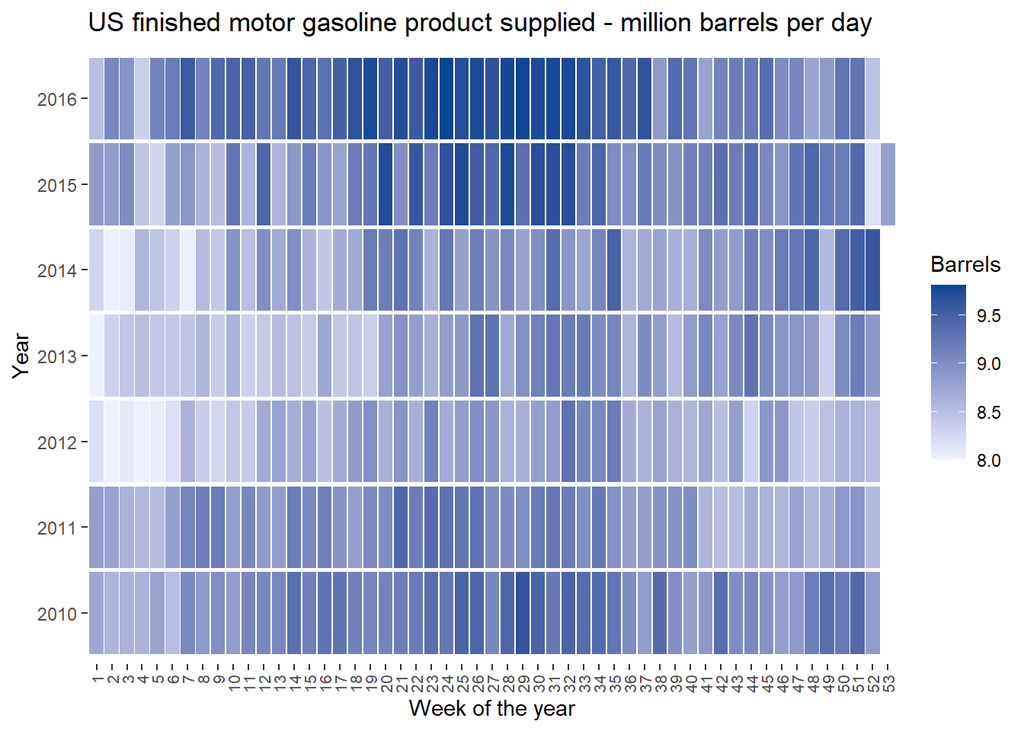

## Exercise HM. 2 - Pedestrians dataset

The dataset `pedestrian`, loaded along with the `fpp3` library, contains hourly pedestrian counts from 2015-01-01 to 2016-12-31 at 4 sensors in the city of Melbourne.

The code below filters data for a specific sensor and then aggregates the data to compute the total pedestrian counts per day at the location of this sensor. It then creates variables signalling the year, the month and the day of the month associated to each day and filters for observations in the year 2016. The result is stored in `aux_ped`

- **NOTE:** the functions `year()`, `month()` and `mday()` are part of the `lubridate` package, which was loaded along with `fpp3`.

```r
aux_ped <-
  pedestrian %>%

    # Ensure data is a tibble
    as_tibble() %>%

    # Filter data for a specific sensor
    filter(Sensor == "Birrarung Marr") %>%

    # Compute
    group_by(Date) %>%
    summarise(
      pedestrians = sum(Count)
    ) %>%

    # Create variables for year, month and day of the month
    mutate(
      year = year(Date),
      month = month(Date, label = TRUE, abbr = FALSE),
      mday = mday(Date)
    ) %>%

    # Filter for observations in 2016
    filter(year == 2016)

aux_ped
```

```
# A tibble: 309 × 5
   Date       pedestrians  year month    mday
   <date>           <int> <dbl> <ord>   <int>
 1 2016-01-01        8726  2016 January     1
 2 2016-01-02       17895  2016 January     2
 3 2016-01-03        6552  2016 January     3
 4 2016-01-04        7103  2016 January     4
 5 2016-01-05        7805  2016 January     5
 6 2016-01-06       13050  2016 January     6
 7 2016-01-07        8185  2016 January     7
 8 2016-01-08        8234  2016 January     8
 9 2016-01-09       21176  2016 January     9
10 2016-01-10        6219  2016 January    10
# … with 299 more rows
```

Use the dataset `aux_ped` to create the following calendar heatmap:

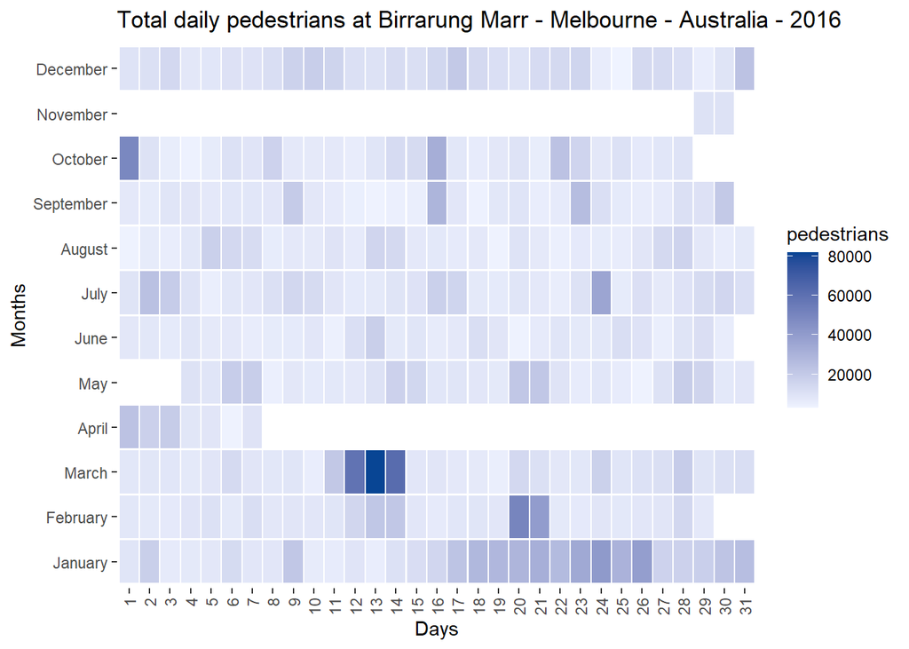

## Exercise HM. 3 - New York City Flights

The code below is very similar to the code in exercise LP. 2 computing the dataframe `delays`, with the difference being that now the averages will be computed per week-day. Refer to that exercise for the details:

```r
# Load lubridate if it is not loaded
# Load nycflights if it is not loaded
library(nycflights13)
library(lubridate) # Loads lubridate in case it is not loaded.
                   # This should not be placed here, but I put it to prevent
                   # errors in your code. Place it at the beginning of the document
library(tidyverse) # Loads tidyverse in case it is not loaded.
                   # This should not be placed here, but I put it to prevent
                   # errors in your code. Place it at the beginning of the document

delays_wday <-

  flights %>%

    # 1. Create a new date column and the corresponding week_day
    mutate(
      date = make_date(year, month, day),

      # Compute the weekday from the date.
        # label = TRUE - character format instead of number
        # abbr = TRUE - abbreviated format instead of full format
      wday = wday(date, label = TRUE, abbr = TRUE)
    ) %>%

    # 2. group_by and summarise
    group_by(origin, month, wday) %>%
    summarise(
      av_delay = mean(arr_delay, na.rm = TRUE),
      max_delay = max(arr_delay, na.rm = TRUE),
      min_delay = min(arr_delay, na.rm = TRUE)
    ) %>%

    # So that subsequent operations are not performed group-wise
    ungroup()
delays_wday
```

```
# A tibble: 252 × 6
   origin month wday  av_delay max_delay min_delay
   <chr>  <int> <ord>    <dbl>     <dbl>     <dbl>
 1 EWR        1 Sun      14.5        262       -61
 2 EWR        1 Mon       7.30       271       -43
 3 EWR        1 Tue       8.34       456       -48
 4 EWR        1 Wed      25.0        497       -52
 5 EWR        1 Thu      18.7       1109       -53
 6 EWR        1 Fri      11.4        364       -61
 7 EWR        1 Sat      -3.63       270       -46
 8 EWR        2 Sun       2.97       773       -53
 9 EWR        2 Mon      14.0        300       -40
10 EWR        2 Tue       9.16       266       -70
# … with 242 more rows
```

As you can see `delays_wday` provides the average delay per month for every week_day. Using `delays_wday` produce the heatmap below:

HINTS:

- use `ylab("month")`

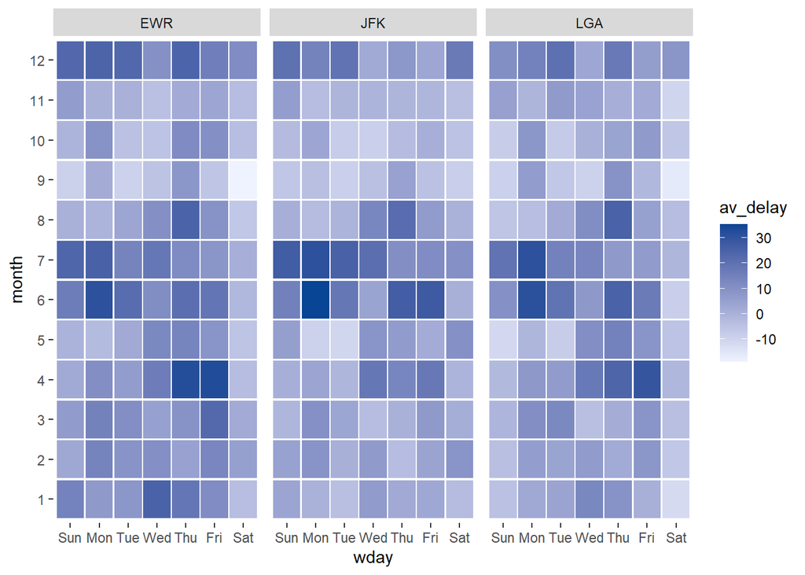